# Assignment_ML

by Prakhar Gupta

### Background

Using devices such as Jawbone Up, Nike FuelBand, and Fitbit it is now possible to collect a large amount of data about personal activity relatively inexpensively. These type of devices are part of the quantified self movement – a group of enthusiasts who take measurements about themselves regularly to improve their health, to find patterns in their behavior, or because they are tech geeks. One thing that people regularly do is quantify how much of a particular activity they do, but they rarely quantify how well they do it. In this project, your goal will be to use data from accelerometers on the belt, forearm, arm, and dumbell of 6 participants. They were asked to perform barbell lifts correctly and incorrectly in 5 different ways. More information is available from the website here: * * * http://web.archive.org/web/20161224072740/http:/groupware.les.inf.puc-rio.br/har (see the section on the Weight Lifting Exercise Dataset).

### Data

The training data for this project are available here:

- https://d396qusza40orc.cloudfront.net/predmachlearn/pml-training.csv

The test data are available here:

- https://d396qusza40orc.cloudfront.net/predmachlearn/pml-testing.csv

The data for this project come from this source: http://web.archive.org/web/20161224072740/http:/groupware.les.inf.puc-rio.br/har. If you use the document you create for this class for any purpose please cite them as they have been very generous in allowing their data to be used for this kind of assignment.

## Environment Preparation

Load all the required libraries

```r
library(knitr)
library(caret)
library(rpart)
library(rpart.plot)
library(rattle)
library(randomForest)
library(corrplot)
library(RColorBrewer)
set.seed(1234)
```

### Read the Data

After downloading the data from the data source, read the two csv files

```r
training  <- 'pml-training.csv'
quizdata   <- 'pml-testing.csv'

train_data <- read.csv(training, strip.white = TRUE, na.strings = c("NA",""))
quiz_data  <- read.csv(quizdata,  strip.white = TRUE, na.strings = c("NA",""))

dim(train_data)
```

```
## [1] 19622   160
```

```r
dim(quiz_data)
```

```
## [1]  20 160
```

The training data set contains 19622 observations and 160 variables and testing data set contains 20 observations and 160 variables.

### partitioned the train data

I’ll split the training data into training and testing partitions and use the pml-testing.csv as a validation sample

```r
set.seed(127)

in_train  <- createDataPartition(train_data$classe, p=0.75, list=FALSE)
train_set <- train_data[ in_train, ]
test_set  <- train_data[-in_train, ]

dim(train_set)
```

```
## [1] 14718   160
```

```r
dim(test_set)
```

```
## [1] 4904  160
```

### Clean Data

There are plenty of NA, that can be removed with the cleaning procedures below. The Near Zero variance (NZV) variables are also removed and the ID variables as well.

```r
nzv_var <- nearZeroVar(train_set)


train_set <- train_set[ , -nzv_var]
test_set  <- test_set [ , -nzv_var]

dim(train_set)
```

```
## [1] 14718   126
```

```r
dim(test_set)
```

```
## [1] 4904  126
```

## Remove variables that are NA. A threshlod of 95 % is selected.

```r
allna    <- sapply(train_set, function(x) mean(is.na(x))) > 0.95
train_set <- train_set[, allna==FALSE]
test_set  <- test_set[, allna==FALSE]

dim(train_set)
```

```
## [1] 14718    59
```

```r
dim(test_set)
```

```
## [1] 4904   59
```

## remove identification variables (columns 1 to 5)

```r
train_set <- train_set[, -(1:5)]
test_set  <- test_set[, -(1:5)]
dim(train_set)
```

```
## [1] 14718    54
```

```r
dim(test_set)
```

```
## [1] 4904   54
```

As per the cleaning process above, the number of variables for the analysis has been reduced to 54 only.

### Correlation Analysis

A correlation matrix among variables.Select “FPC” for the first principal component order.

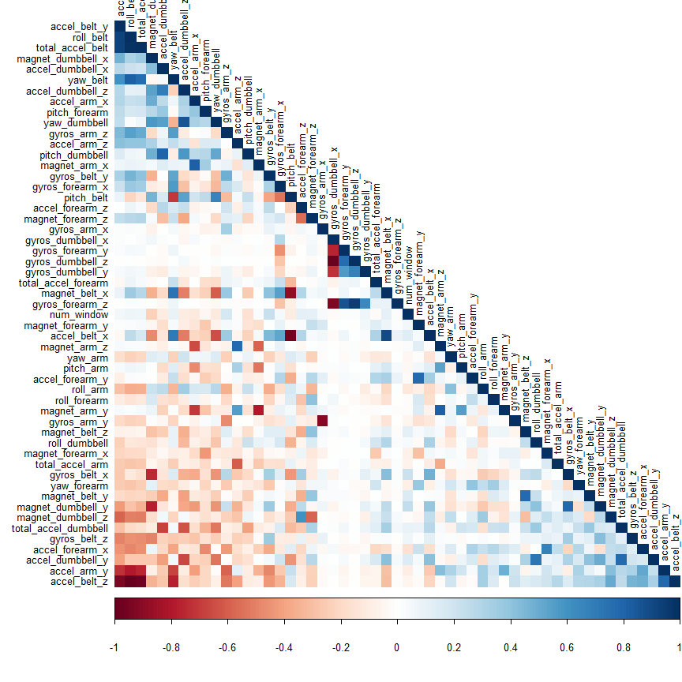

```r
corrmatrix <-cor(train_set[, -length(names(train_set))])

corrplot(corrmatrix, order = "FPC", method = "color", type = "lower",
         tl.cex = 0.8, tl.col = rgb(0, 0, 0))
```

The highly correlated variables are shown in dark colors in the graph above.The highly correlated their colors are either dark blue (for a positive correlation) or dark red (for a negative corraltions).

### Prediction Model

The methods are: * Random Forests, * Decision Tree and * Generalized Boosted Model described below.

A Confusion Matrix is plotted at the end of each analysis for better visualize the accuracy of the models.

## A)Random Forest

- use Random Forest method with Cross Validation, 3 folds
- number =3 is # folds of the training data
- Cross Validation achieved with trainControl method set to “cv”
- ntree =250 is the number of tree

```r
#model fit
set.seed(1234)
controlRF <- trainControl(method="cv", number=3, verboseIter=FALSE)
modelRf  <- train(classe ~ ., data=train_set, method="rf",
                          trControl=controlRF,ntree=250)
modelRf$finalModel
```

```
##
## Call:
##  randomForest(x = x, y = y, ntree = 250, mtry = param$mtry)
##                Type of random forest: classification
##                      Number of trees: 250
## No. of variables tried at each split: 27
##
##         OOB estimate of  error rate: 0.19%
## Confusion matrix:
##      A    B    C    D    E  class.error
## A 4184    0    0    0    1 0.0002389486
## B    7 2836    4    1    0 0.0042134831
## C    0    1 2566    0    0 0.0003895598
## D    0    0    8 2404    0 0.0033167496
## E    0    0    0    6 2700 0.0022172949
```

```r
# prediction on Test dataset
#Check the accuracy of the model by comparing the predictions to the actual results
predictRf <- predict(modelRf, newdata=test_set)
confMatRandForest <- confusionMatrix(predictRf, test_set$classe)
confMatRandForest
```

```
## Confusion Matrix and Statistics
##
##           Reference
## Prediction    A    B    C    D    E
##          A 1395    1    0    0    0
##          B    0  946    4    0    0
##          C    0    2  851    3    0
##          D    0    0    0  800    4
##          E    0    0    0    1  897
##
## Overall Statistics
##
##                Accuracy : 0.9969
##                  95% CI : (0.995, 0.9983)
##     No Information Rate : 0.2845
##     P-Value [Acc > NIR] : < 2.2e-16
##
##                   Kappa : 0.9961
##  Mcnemar's Test P-Value : NA
##
## Statistics by Class:
##
##                      Class: A Class: B Class: C Class: D Class: E
## Sensitivity            1.0000   0.9968   0.9953   0.9950   0.9956
## Specificity            0.9997   0.9990   0.9988   0.9990   0.9998
## Pos Pred Value         0.9993   0.9958   0.9942   0.9950   0.9989
## Neg Pred Value         1.0000   0.9992   0.9990   0.9990   0.9990
## Prevalence             0.2845   0.1935   0.1743   0.1639   0.1837
## Detection Rate         0.2845   0.1929   0.1735   0.1631   0.1829
## Detection Prevalence   0.2847   0.1937   0.1746   0.1639   0.1831
## Balanced Accuracy      0.9999   0.9979   0.9970   0.9970   0.9977
```

```r
accuracy <- postResample(predictRf, test_set$classe)
accuracy
```

```
##  Accuracy     Kappa
## 0.9969413 0.9961310
```

```r
outof_sample_error <- 1 - as.numeric(confusionMatrix(test_set$classe, predictRf)$overall[1])
outof_sample_error
```

```
## [1] 0.003058728
```

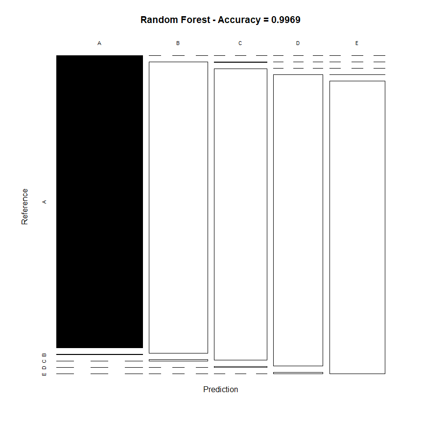

```r
#plot matrix results

plot(confMatRandForest$table, col = confMatRandForest$byClass,
     main = paste("Random Forest - Accuracy =",
                  round(confMatRandForest$overall['Accuracy'], 4)))
```

The out-of-sample error of 003058728 or 0.30%.

Accuracy is very high, at 0.9969, and this figure lies within the 95% confidence interval.

## B)Decision Trees

Created decision tree model.

[figure not shown]

```r
set.seed(1234)
modFitDecTree <- rpart(classe ~ ., data=train_set, method="class")
fancyRpartPlot(modFitDecTree)
```

```r
# prediction on Test dataset
#Check the accuracy of the model by comparing the predictions to the actual results
predictDecTree <- predict(modFitDecTree, newdata=test_set, type="class")
confMatDecTree <- confusionMatrix(predictDecTree, test_set$classe)
confMatDecTree
```

```
## Confusion Matrix and Statistics
##
##           Reference
## Prediction    A    B    C    D    E
##          A 1230  173   32   43   31
##          B  104  612   77  113   59
##          C   10   55  659   92   48
##          D   24   53   39  471   78
##          E   27   56   48   85  685
##
## Overall Statistics
##
##                Accuracy : 0.7457
##                  95% CI : (0.7333, 0.7579)
##     No Information Rate : 0.2845
##     P-Value [Acc > NIR] : < 2.2e-16
##
##                   Kappa : 0.6772
##  Mcnemar's Test P-Value : 2.492e-13
##
## Statistics by Class:
##
##                      Class: A Class: B Class: C Class: D Class: E
## Sensitivity            0.8817   0.6449   0.7708  0.58582   0.7603
## Specificity            0.9205   0.9107   0.9494  0.95268   0.9460
## Pos Pred Value         0.8151   0.6342   0.7627  0.70827   0.7603
## Neg Pred Value         0.9514   0.9144   0.9515  0.92144   0.9460
## Prevalence             0.2845   0.1935   0.1743  0.16395   0.1837
## Detection Rate         0.2508   0.1248   0.1344  0.09604   0.1397
## Detection Prevalence   0.3077   0.1968   0.1762  0.13560   0.1837
## Balanced Accuracy      0.9011   0.7778   0.8601  0.76925   0.8532
```

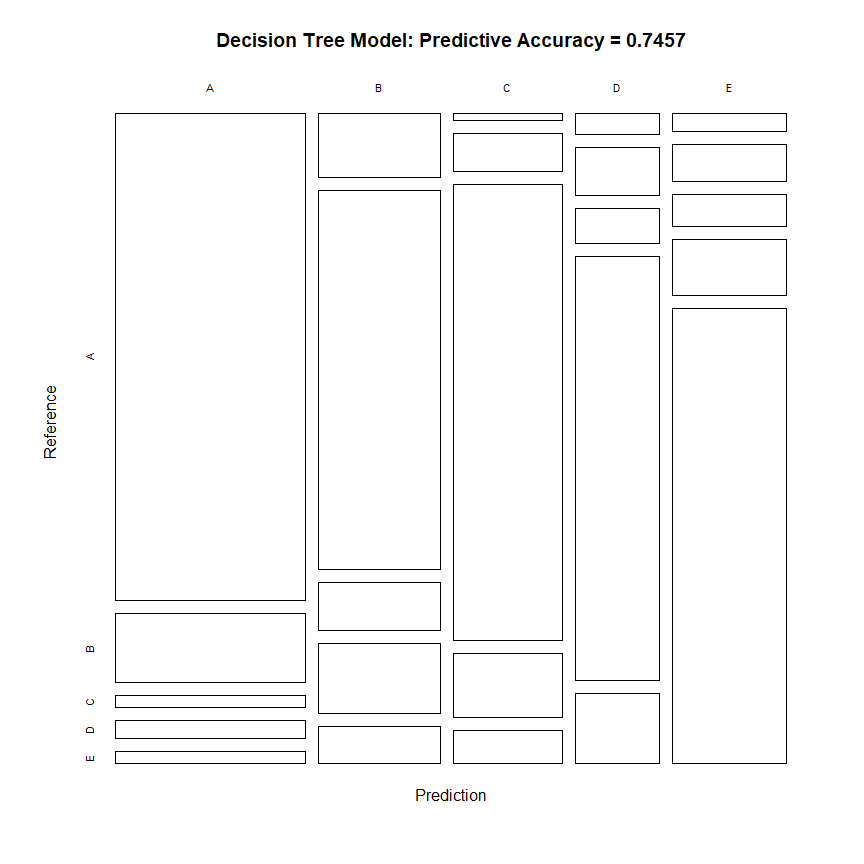

```r
plot(confMatDecTree$table, col = confMatDecTree$byClass,
     main = paste("Decision Tree Model: Predictive Accuracy =",
                  round(confMatDecTree$overall['Accuracy'], 4)))
```

The decision tree accuracy is 74.57%

## C)Generalized Boosted Model(GBM)

```r
set.seed(1234)
controlGBM  <- trainControl(method = "repeatedcv", number = 5, repeats = 2)
fit_GBM  <- train(classe ~ ., data = train_set, method = "gbm",
                  trControl = controlGBM, verbose = FALSE)
fit_GBM$finalModel
```

```
## A gradient boosted model with multinomial loss function.
## 150 iterations were performed.
## There were 53 predictors of which 40 had non-zero influence.
```

```r
# prediction on Test dataset
#Check the accuracy of the model by comparing the predictions to the actual results
predictGBM <- predict(fit_GBM, newdata=test_set)
confMatGBM <- confusionMatrix(predictGBM, test_set$classe)
confMatGBM
```

```
## Confusion Matrix and Statistics
##
##           Reference
## Prediction    A    B    C    D    E
##          A 1389    8    0    3    1
##          B    4  929    8    4    4
##          C    0   12  843    6    0
##          D    2    0    3  790   14
##          E    0    0    1    1  882
##
## Overall Statistics
##
##                Accuracy : 0.9855
##                  95% CI : (0.9818, 0.9887)
##     No Information Rate : 0.2845
##     P-Value [Acc > NIR] : < 2.2e-16
##
##                   Kappa : 0.9817
##  Mcnemar's Test P-Value : NA
##
## Statistics by Class:
##
##                      Class: A Class: B Class: C Class: D Class: E
## Sensitivity            0.9957   0.9789   0.9860   0.9826   0.9789
## Specificity            0.9966   0.9949   0.9956   0.9954   0.9995
## Pos Pred Value         0.9914   0.9789   0.9791   0.9765   0.9977
## Neg Pred Value         0.9983   0.9949   0.9970   0.9966   0.9953
## Prevalence             0.2845   0.1935   0.1743   0.1639   0.1837
## Detection Rate         0.2832   0.1894   0.1719   0.1611   0.1799
## Detection Prevalence   0.2857   0.1935   0.1756   0.1650   0.1803
## Balanced Accuracy      0.9961   0.9869   0.9908   0.9890   0.9892
```

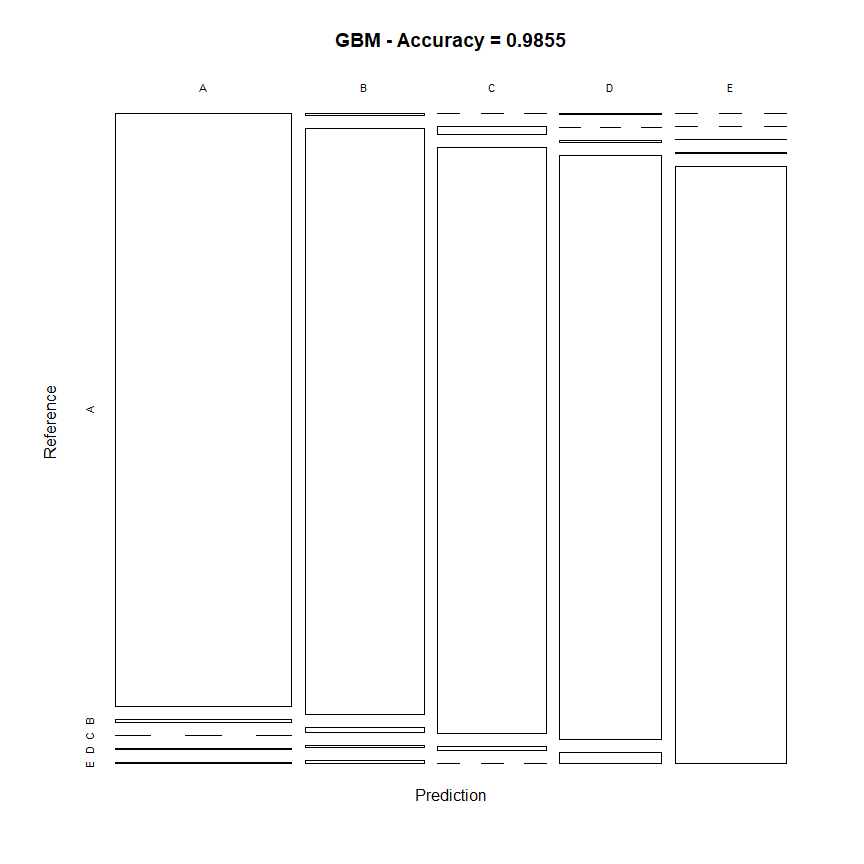

```r
# plot matrix results
plot(confMatGBM$table, col = confMatGBM$byClass,
     main = paste("GBM - Accuracy =", round(confMatGBM$overall['Accuracy'], 4)))
```

The predictive accuracy of the GBM is relatively high at 98.55 %.

### Conclusion

The accuracy of the 3 regression modeling methods above are:

- Random Forest : 0.9969
- Decision Tree : 0.7457
- GBM : 0.9855